# 2. Prediction of properties: QSAR model results analysis

## Keto

```python
keto_biowin = pd.read_csv((Projectdir + '\\selection\\keto_biowin.txt'), sep="\t", header=None,
                          names=["Biowin1", "Biowin2","Biowin3", "Biowin4","Biowin5","Biowin6","Biowin7","SMILES"])
keto_logkow = pd.read_csv((Projectdir + '\\selection\\keto_logkow.txt'), sep="\t", header=None,
                          names=["log Kow","SMILES"])
keto_mpbpvp = pd.read_csv((Projectdir + '\\selection\\keto_mpbpvp.txt'), sep="\t", header=None,
                          names=["bp",'mp','vp',"SMILES"])
```

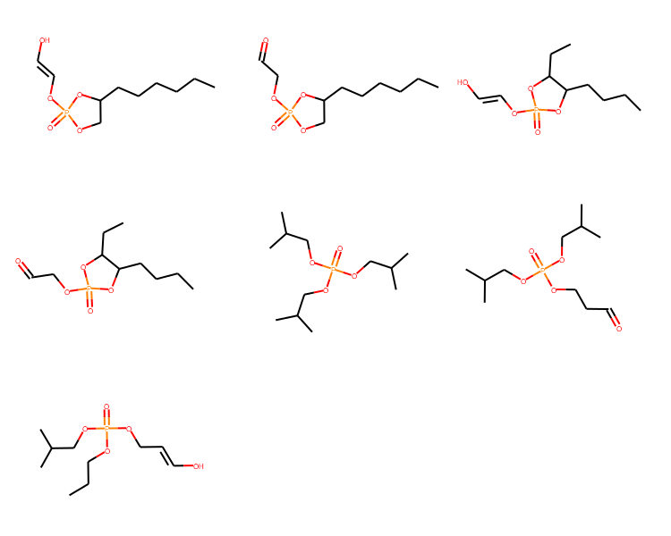

```python
drawsmileslist(keto_biowin['SMILES'])
```

```python
nt_keto_mpbpvp = keto_mpbpvp[keto_mpbpvp['SMILES']!= tibp]
nt_keto_biowin = keto_biowin[keto_biowin['SMILES']!= tibp]
nt_keto_logkow = keto_logkow[keto_logkow['SMILES']!= tibp]
```

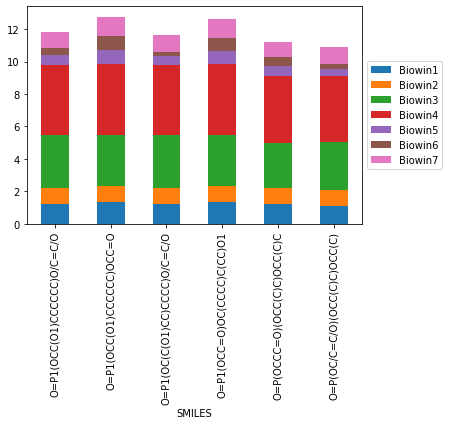

```python
nt_keto_biowin.plot(x= 'SMILES', kind='bar', stacked=True)
plt.legend(loc='center left', bbox_to_anchor=(1, 0.5))
```

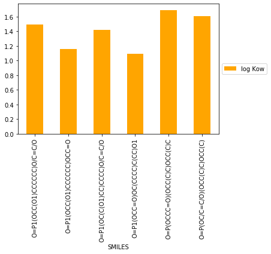

```python
nt_keto_logkow.plot(x= 'SMILES', kind='bar', color = 'orange')
plt.legend(loc='center left', bbox_to_anchor=(1, 0.5))
#plt.axhline(y=3,linewidth=1, color='red')
```

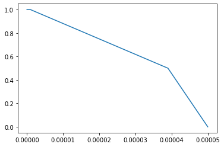

```python
vp_desirability_points = [{"x": 0, "y": 1},{"x": (9.98E-7), "y": 1},{"x": (3.9E-5), "y": 0.5},{"x": (5.0E-5), "y": 0}]

vp_desirability = pd.DataFrame(vp_desirability_points)
plt.plot(vp_desirability['x'],vp_desirability['y'])
```

```
0    3.690000e-07
1    5.820000e-05
2    4.720000e-07
3    7.190000e-05
4    1.280000e-02
5    1.500000e-04
6    1.200000e-06
Name: vp, dtype: float64
```

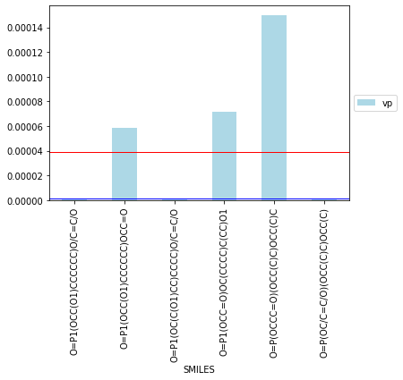

```python
print(keto_mpbpvp['vp'])
nt_keto_mpbpvp[['SMILES','vp']].plot(x= 'SMILES', kind='bar', color = 'lightblue')
plt.legend(loc='center left', bbox_to_anchor=(1, 0.5))
plt.axhline(y=(3.9E-5),linewidth=1, color='red') #upper volatility level
plt.axhline(y=(9.98E-7),linewidth=1, color='blue') #lower volatility level
```

## Thiophosphateester test set

We considered to also use a different inital fragment in the molecules *generation* as in input to OMG. This would be a thioester group.

However, there was a problem with OMG, it cannot generate any structure with the thiophosphate starting fragment, I was not able to find out why. I generated a quick and small set of organothioesters manually by substituting O with S in some ready biodegradable molecules from previous runs: Out of 11 molecules in that set, 8 classified as ready biodegradable. Compared to the phosphateesters, at least some of the respective thiophosphateesters score even better in various Biowin models.

So, this quick test series suggests that we should not ignore the thioesters, at least not on the basis of biodegradability. However, I don't manage to do a structure generation run with them on OMG. This could be a point of departure for future work.

```python
OthioPsdf =Chem.SDMolSupplier(r'C:\Users\Hannah\Documents\Master UvA\master project\OMG\organothiophosphates_forbiowin.sdf')
OthioPsmi = []
for mol in OthioPsdf:
    OthioPsmi.append(Chem.MolToSmiles(mol))
writetxt(OthioPsmi, 'OthioPsmiles', r'C:\Users\Hannah\Documents\Master UvA\master project\OMG')
```

```
DataFrame is empty, no ready biodegradable molecules
```

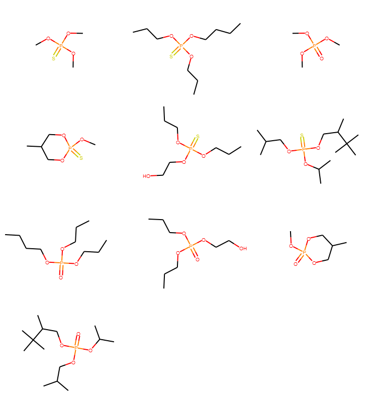

```python
OthioPbiowin = pd.read_csv((Projectdir + '\\OthioP_biowin.txt'), sep="\t", header=None,
                          names=["Biowin1", "Biowin2","Biowin3", "Biowin4","Biowin5","Biowin6","Biowin7","SMILES"])
ready_biodegradable_show(OthioPbiowin)
drawsmileslist(OthioPbiowin['SMILES'])
```

```
8 ready biodegradable molecules in table, out of  11 total
Ready biodegradable:
```

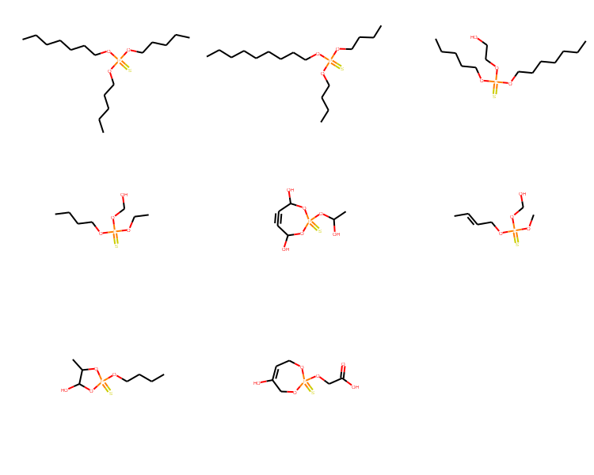

```python
OthioPBIODEGbiowin = pd.read_csv((Projectdir + '\\OthioPBIODEG_biowin.txt'), sep="\t", header=None,
                          names=["Biowin1", "Biowin2","Biowin3", "Biowin4","Biowin5","Biowin6","Biowin7","SMILES"])
ready_biodegradable_show(OthioPBIODEGbiowin)
#drawsmileslist(OthioPbiowin['SMILES'])
```

```
Log Kow below 4.5:
```

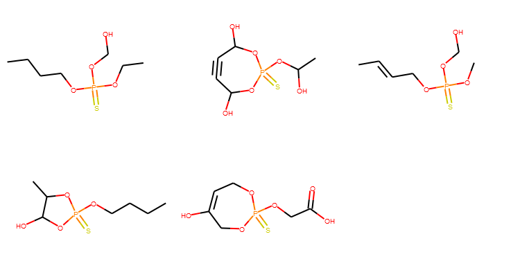

```python
OthioPBIODEG_Kow = pd.read_csv((Projectdir + '\\OthioPBIODEG_Kow.txt'), sep="\t", header=None,
                          names=["log Kow", 'SMILES'])
print('Log Kow below 4.5:')
drawsmileslist(OthioPBIODEG_Kow[OthioPBIODEG_Kow['log Kow']<4.5]['SMILES'])
```

```
11 ready biodegradable molecules in table, out of  11 total
Ready biodegradable:
```

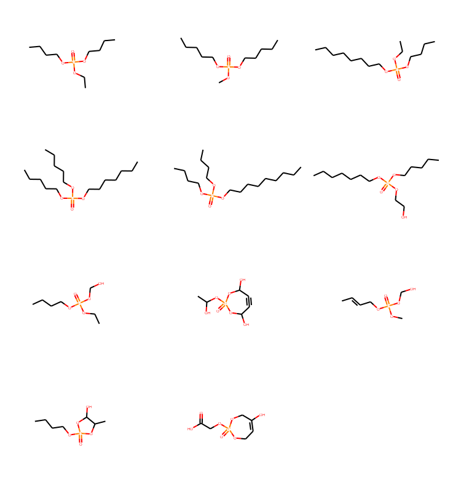

```python
OPBIODEGbiowin = pd.read_csv((Projectdir + '\\OPBIODEG_biowin.txt'), sep="\t", header=None,
                          names=["Biowin1", "Biowin2","Biowin3", "Biowin4","Biowin5","Biowin6","Biowin7","SMILES"])
ready_biodegradable_show(OPBIODEGbiowin)
```

```python
biowin_better_than_original(OthioPBIODEGbiowin, 'Biowin6', 'OP',OPBIODEGbiowin)
```

```
Better than  OP  in Biowin6 :
 2
```

|  | Biowin1 | Biowin2 | Biowin3 | Biowin4 | Biowin5 | Biowin6 | Biowin7 | SMILES |
| --- | --- | --- | --- | --- | --- | --- | --- | --- |
| 5 | 1.2817 | 1.0 | 3.3882 | 4.5097 | 0.6507 | 0.6057 | 1.0131 | CCCCCCCOP(=S)(OCCO)OCCCCC |
| 6 | 1.2200 | 1.0 | 3.3068 | 4.3823 | 0.5969 | 0.5640 | 1.1489 | CCCCOP(=S)(OCC)OCO |